# Компьютерная работа №1 Многомерные статистические методы 2020-21 гг. — 2 курс

Теперь рассмотрим случай после удаления выбросов:

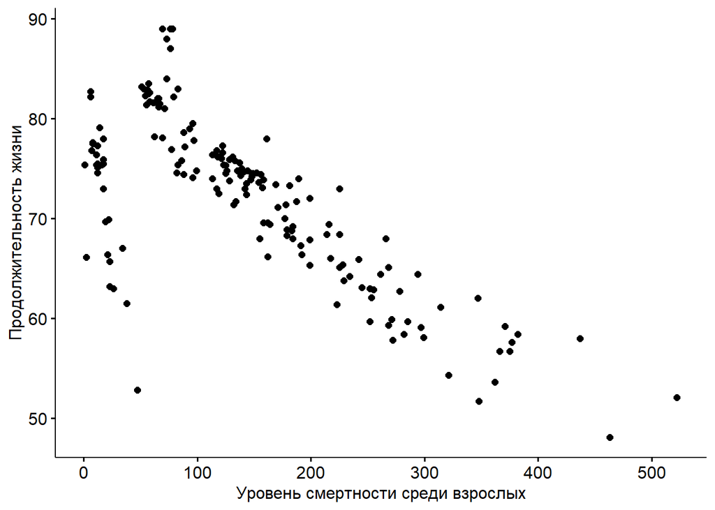

```r
ggscatter(data_new, x = "Adult_mort", y = "Life_exp", xlab = "Уровень смертности среди взрослых", ylab = "Продолжительность жизни")
```

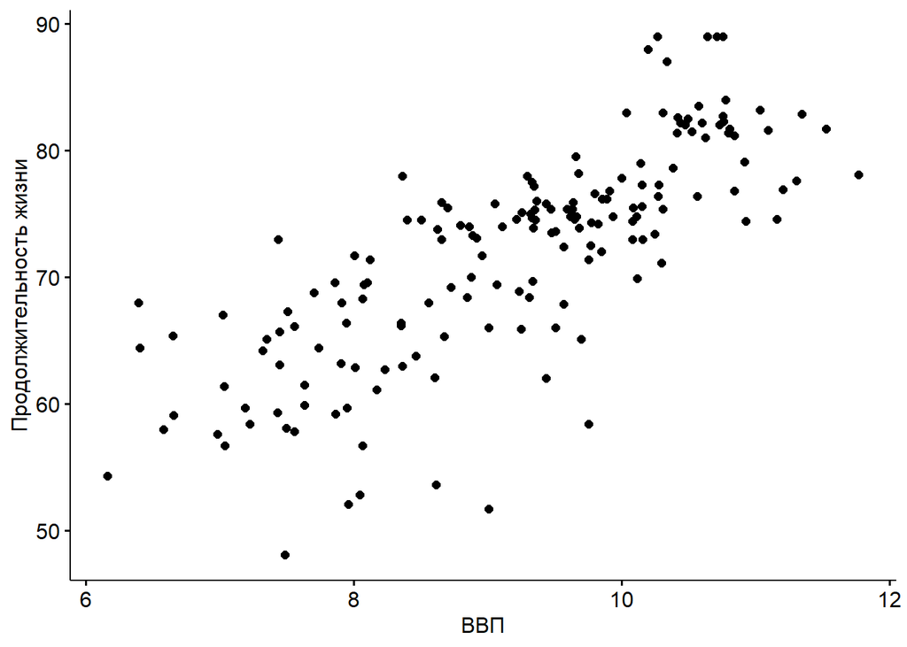

```r
ggscatter(data_new, x = "GDP", y = "Life_exp", xlab = "ВВП", ylab = "Продолжительность жизни")
```

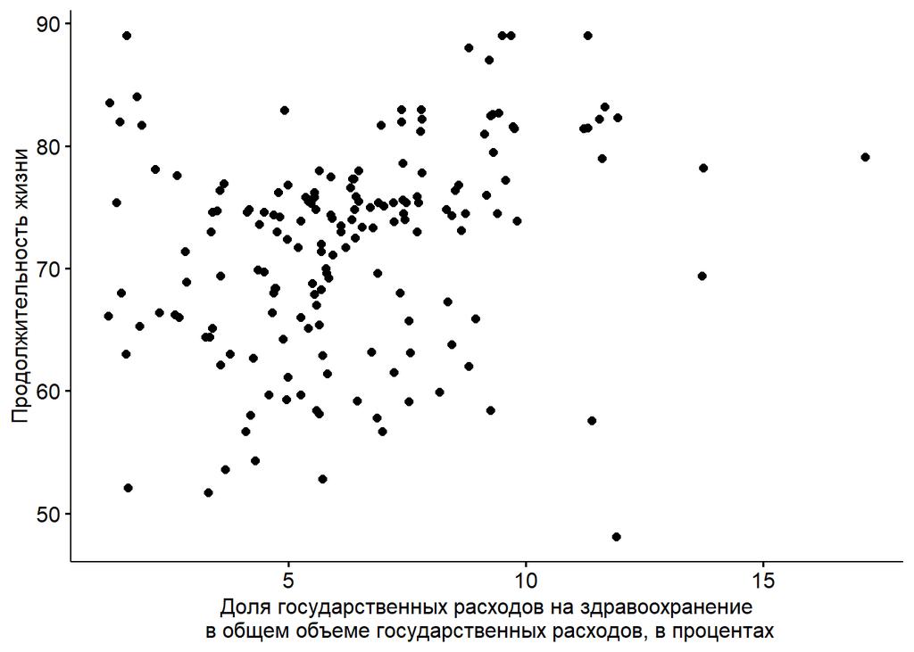

```r
ggscatter(data_new, x = "Total_exp", y = "Life_exp", xlab = "Доля государственных расходов на здравоохранение\n в общем объеме государственных расходов, в процентах", ylab = "Продолжительность жизни")
```

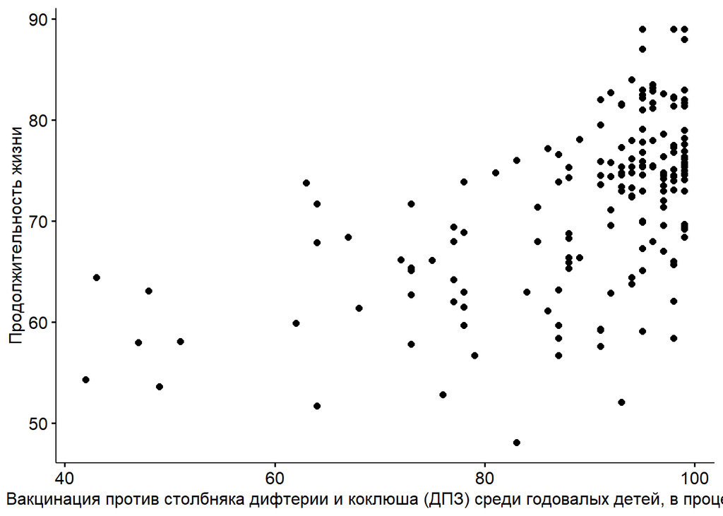

```r
ggscatter(data_new, x = "Dipht", y = "Life_exp", xlab = "Вакцинация против столбняка дифтерии и коклюша (ДПЗ) среди годовалых детей, в процентах", ylab = "Продолжительность жизни")
```

##### **5.2**

Далее построим и проинтерпретируем матрицу парных коэффициентов корреляции. Рассмотрим сначала случай до удаления аномальных наблюдений.

Корреляционная матрица для количественных переменных:

```r
cor_m1 <- cor(data1[,-1], method = 'pearson')
cor_m1
```

```
                 Life_exp Adult_mort    Alcohol  Total_exp       Dipht
Life_exp        1.0000000 -0.7586202  0.5261349  0.3166411  0.37592385
Adult_mort     -0.7586202  1.0000000 -0.2892553 -0.1732955 -0.30284597
Alcohol         0.5261349 -0.2892553  1.0000000  0.3262400  0.16362990
Total_exp       0.3166411 -0.1732955  0.3262400  1.0000000  0.20589146
Dipht           0.3759239 -0.3028460  0.1636299  0.2058915  1.00000000
GDP             0.7702578 -0.6106848  0.5260696  0.2086654  0.31421263
Thinness_5_9   -0.5874316  0.4014455 -0.4423978 -0.3465965 -0.07906882
Thinness_10_19 -0.5560773  0.3728297 -0.4347167 -0.3102189 -0.05349208
Schooling       0.7927521 -0.5552534  0.5459687  0.2867160  0.33921167
                      GDP Thinness_5_9 Thinness_10_19  Schooling
Life_exp        0.7702578  -0.58743158    -0.55607725  0.7927521
Adult_mort     -0.6106848   0.40144546     0.37282972 -0.5552534
Alcohol         0.5260696  -0.44239785    -0.43471668  0.5459687
Total_exp       0.2086654  -0.34659647    -0.31021886  0.2867160
Dipht           0.3142126  -0.07906882    -0.05349208  0.3392117
GDP             1.0000000  -0.45660513    -0.43432806  0.8010991
Thinness_5_9   -0.4566051   1.00000000     0.95502449 -0.5609470
Thinness_10_19 -0.4343281   0.95502449     1.00000000 -0.5521994
Schooling       0.8010991  -0.56094695    -0.55219936  1.0000000
```

Наиболее сильная положительная связь наблюдается между переменными `Thinness_5_9` и `Thinness_10_19` (0,96), `Life_exp` и `Schooling` ($\hat{\rho}= 0,79$), также `GDP` И `Schooling` ($\hat{\rho}= 0,8$), `Life_exp` и `GDP` ($\hat{\rho}= 0,77$). Наиболее сильная обратная связь наблюдается между переменными `Life_exp` и `Adult_mort` ($\hat{\rho}= -0,76$), `Life_exp` и `Thinness_5_9` ($\hat{\rho}= -0,59$), `GDP` и `Adult_mort` ($\hat{\rho}= -0,61$). Самая слабая связь между переменными `Dipht` и `Thinness_10_19` ($\hat{\rho}= -0,05$). В целом, видим, что присутствует довольно сильная – в большинстве случаев – связь между зависимой переменной `Life_exp` и остальными объясняющими переменными, за исключением `Total_exp` и `Dipht`, где коэффициент корреляции по модулю меньше 0,4 (умеренная связь).

Корреляционная матрица для количественных переменных с p-value:

```r
cor_m2 <- rcorr(as.matrix(data1[,-1]), type = 'pearson')
cor_m2
```

```
               Life_exp Adult_mort Alcohol Total_exp Dipht   GDP Thinness_5_9
Life_exp           1.00      -0.76    0.53      0.32  0.38  0.77        -0.59
Adult_mort        -0.76       1.00   -0.29     -0.17 -0.30 -0.61         0.40
Alcohol            0.53      -0.29    1.00      0.33  0.16  0.53        -0.44
Total_exp          0.32      -0.17    0.33      1.00  0.21  0.21        -0.35
Dipht              0.38      -0.30    0.16      0.21  1.00  0.31        -0.08
GDP                0.77      -0.61    0.53      0.21  0.31  1.00        -0.46
Thinness_5_9      -0.59       0.40   -0.44     -0.35 -0.08 -0.46         1.00
Thinness_10_19    -0.56       0.37   -0.43     -0.31 -0.05 -0.43         0.96
Schooling          0.79      -0.56    0.55      0.29  0.34  0.80        -0.56
               Thinness_10_19 Schooling
Life_exp                -0.56      0.79
Adult_mort               0.37     -0.56
Alcohol                 -0.43      0.55
Total_exp               -0.31      0.29
Dipht                   -0.05      0.34
GDP                     -0.43      0.80
Thinness_5_9             0.96     -0.56
Thinness_10_19           1.00     -0.55
Schooling               -0.55      1.00

n= 183


P
               Life_exp Adult_mort Alcohol Total_exp Dipht  GDP    Thinness_5_9
Life_exp                0.0000     0.0000  0.0000    0.0000 0.0000 0.0000
Adult_mort     0.0000              0.0000  0.0190    0.0000 0.0000 0.0000
Alcohol        0.0000   0.0000             0.0000    0.0269 0.0000 0.0000
Total_exp      0.0000   0.0190     0.0000            0.0052 0.0046 0.0000
Dipht          0.0000   0.0000     0.0269  0.0052           0.0000 0.2873
GDP            0.0000   0.0000     0.0000  0.0046    0.0000        0.0000
Thinness_5_9   0.0000   0.0000     0.0000  0.0000    0.2873 0.0000
Thinness_10_19 0.0000   0.0000     0.0000  0.0000    0.4720 0.0000 0.0000
Schooling      0.0000   0.0000     0.0000  0.0000    0.0000 0.0000 0.0000
               Thinness_10_19 Schooling
Life_exp       0.0000         0.0000
Adult_mort     0.0000         0.0000
Alcohol        0.0000         0.0000
Total_exp      0.0000         0.0000
Dipht          0.4720         0.0000
GDP            0.0000         0.0000
Thinness_5_9   0.0000         0.0000
Thinness_10_19                0.0000
Schooling      0.0000
```

Итак, получив значения p-value, можем сделать вывод о статистической значимости парных коэффициентов корреляции.Все коэффиенты, для которых p-value больше 0,05, являются незначимыми на уровне значимости 0,95. Как и стоило ожидать, очень высокий p-value имеет коэффициент корреляции между `Dipht` и `Thinness_10_19`, между которыми наблюдается отсутствие связи.

Далее подтвердим полученные выводы более наглядно с помощью еще двух способов отображения матрицы парных коэффициентов корреляции.

Корреляционная матрица:

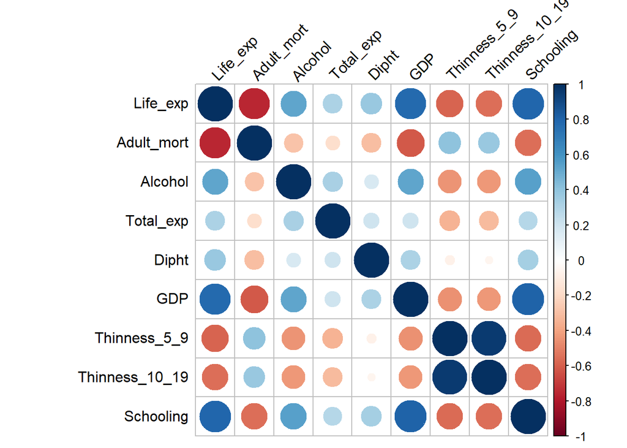

```r
corrplot(as.matrix(cor_m1), type = 'full', method = 'circle', tl.col = 'black', tl.srt = 45)
```

Этот график показывает направление связи между двумя переменными, для которой выше была дана численная интерпретация (красным показана отрицательная зависимость, синим - положительная), а также силу связи между ними (чем более крупный и насыщенный по цвету круг, тем более сильная связь между переменными).

На следующем графике можно наглядно увидеть направление связи (по наклону овала) между двумя переменными (красным показана отрицательная зависимость, синим - положительная), а также силу связи между ними (чем более насыщенный по цвету овал, чем он более вытянут, тем более сильная связь между переменными):

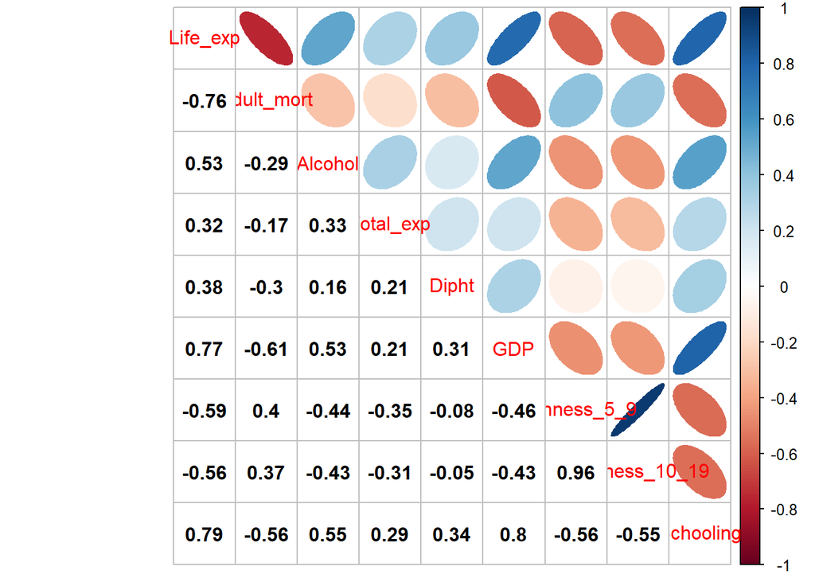

```r
corrplot.mixed(cor(data1[,-1]), lower.col = 'black', upper = 'ellipse')
```

В левой части видим значения парных коэффициентов корреляции, в правой - сами эллипсы, которые визуализируют эти значения.

Теперь построим и проинтерпретируем матрицу парных коэффициентов корреляции ПОСЛЕ удаления аномальных наблюдений.

Корреляционная матрица для количественных переменных:

```r
cor_m11 <- cor(data_new[,-1], method = 'pearson')
cor_m11
```

```
                 Life_exp Adult_mort    Alcohol  Total_exp       Dipht
Life_exp        1.0000000 -0.7565133  0.5095231  0.2709217  0.55584111
Adult_mort     -0.7565133  1.0000000 -0.2645072 -0.1281027 -0.47096226
Alcohol         0.5095231 -0.2645072  1.0000000  0.3200690  0.28928231
Total_exp       0.2709217 -0.1281027  0.3200690  1.0000000  0.18398000
Dipht           0.5558411 -0.4709623  0.2892823  0.1839800  1.00000000
GDP             0.7789244 -0.5892467  0.5341394  0.1674684  0.51227319
Thinness_5_9   -0.5814806  0.3936692 -0.4540549 -0.3413691 -0.16511545
Thinness_10_19 -0.5447824  0.3598727 -0.4463003 -0.3011135 -0.09387283
Schooling       0.7793738 -0.5327962  0.5499583  0.2379678  0.52746828
                      GDP Thinness_5_9 Thinness_10_19  Schooling
Life_exp        0.7789244   -0.5814806    -0.54478242  0.7793738
Adult_mort     -0.5892467    0.3936692     0.35987271 -0.5327962
Alcohol         0.5341394   -0.4540549    -0.44630030  0.5499583
Total_exp       0.1674684   -0.3413691    -0.30111349  0.2379678
Dipht           0.5122732   -0.1651155    -0.09387283  0.5274683
GDP             1.0000000   -0.4677930    -0.44386740  0.8062123
Thinness_5_9   -0.4677930    1.0000000     0.95028357 -0.5522517
Thinness_10_19 -0.4438674    0.9502836     1.00000000 -0.5408283
Schooling       0.8062123   -0.5522517    -0.54082827  1.0000000
```

Наиболее сильная положительная связь наблюдается между переменными `Thinness_5_9` и `Thinness_10_19` ($\hat{\rho}= 0,95$), `Life_exp` и `Schooling` ($\hat{\rho}= 0,78$), также присутствует сильная связь между `GDP` И `Schooling` ($\hat{\rho}= 0,81$), `Life_exp` и `GDP` ($\hat{\rho}= 0,78$). Наиболее сильная обратная связь наблюдается между переменными `Life_exp` и `Adult_mort` ($\hat{\rho}= -0,76$), `Life_exp` и `Thinness_5_9` ($\hat{\rho}= -0,58$), `GDP` и `Adult_mort` ($\hat{\rho}= -0,59$). Самая слабая связь, как и прежде, наблюдается между переменными `Dipht` и `Thinness_10_19` ($\hat{\rho}= -0,09$). В целом, видим, что между зависимой переменной `Life_exp` и остальными объясняющими переменными довольно сильная связь, за исключением `Total_exp`, где коэффициент $\hat{\rho}<0,3$ (очень слабая связь), что весьма странно, учитывая, что `Total_exp` показывает,грубо говоря, траты государства на здравоохранение. Можем отметить, что в результате удаления выбросов сильно возросла связь между `Life_exp` и `Dipht` (была 0,38, стала 0,56).

В целом, связь между переменной `Dipht` и остальными переменными стала еще более сильной после удаления выбросов (выбросы, напомним, были найдены только по переменной `Dipht`).

Корреляционная матрица для количественных переменных с p-value:

```r
cor_m22 <- rcorr(as.matrix(data_new[,-1]), type = 'pearson')
cor_m22
```

```
               Life_exp Adult_mort Alcohol Total_exp Dipht   GDP Thinness_5_9
Life_exp           1.00      -0.76    0.51      0.27  0.56  0.78        -0.58
Adult_mort        -0.76       1.00   -0.26     -0.13 -0.47 -0.59         0.39
Alcohol            0.51      -0.26    1.00      0.32  0.29  0.53        -0.45
Total_exp          0.27      -0.13    0.32      1.00  0.18  0.17        -0.34
Dipht              0.56      -0.47    0.29      0.18  1.00  0.51        -0.17
GDP                0.78      -0.59    0.53      0.17  0.51  1.00        -0.47
Thinness_5_9      -0.58       0.39   -0.45     -0.34 -0.17 -0.47         1.00
Thinness_10_19    -0.54       0.36   -0.45     -0.30 -0.09 -0.44         0.95
Schooling          0.78      -0.53    0.55      0.24  0.53  0.81        -0.55
               Thinness_10_19 Schooling
Life_exp                -0.54      0.78
Adult_mort               0.36     -0.53
Alcohol                 -0.45      0.55
Total_exp               -0.30      0.24
Dipht                   -0.09      0.53
GDP                     -0.44      0.81
Thinness_5_9             0.95     -0.55
Thinness_10_19           1.00     -0.54
Schooling               -0.54      1.00

n= 170


P
               Life_exp Adult_mort Alcohol Total_exp Dipht  GDP    Thinness_5_9
Life_exp                0.0000     0.0000  0.0004    0.0000 0.0000 0.0000
Adult_mort     0.0000              0.0005  0.0960    0.0000 0.0000 0.0000
Alcohol        0.0000   0.0005             0.0000    0.0001 0.0000 0.0000
Total_exp      0.0004   0.0960     0.0000            0.0163 0.0290 0.0000
Dipht          0.0000   0.0000     0.0001  0.0163           0.0000 0.0314
GDP            0.0000   0.0000     0.0000  0.0290    0.0000        0.0000
Thinness_5_9   0.0000   0.0000     0.0000  0.0000    0.0314 0.0000
Thinness_10_19 0.0000   0.0000     0.0000  0.0000    0.2234 0.0000 0.0000
Schooling      0.0000   0.0000     0.0000  0.0018    0.0000 0.0000 0.0000
               Thinness_10_19 Schooling
Life_exp       0.0000         0.0000
Adult_mort     0.0000         0.0000
Alcohol        0.0000         0.0000
Total_exp      0.0000         0.0018
Dipht          0.2234         0.0000
GDP            0.0000         0.0000
Thinness_5_9   0.0000         0.0000
Thinness_10_19                0.0000
Schooling      0.0000
```

Получив значения p-value, можем сделать вывод о статистической значимости парных коэффициентов корреляции. Видно, что все коэффиенты, для которых p-value больше 0,05, являются незначимыми на уровне значимости 0,95: это особенно справедливо, как и раньше, для переменных `Dipht` и `Thinness_10_19`

И снова, как и в случае до удаления выбросов, получим более наглядную форму представления матрицы парных коэффициентов корреляции.

Корреляционная матрица:

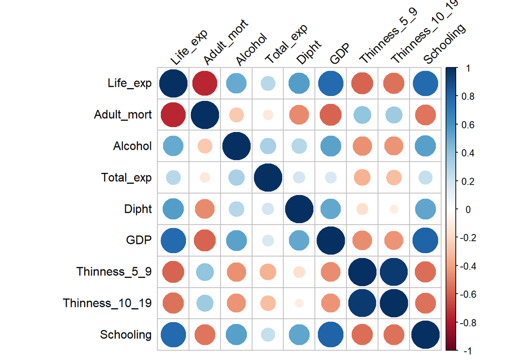

```r
corrplot(as.matrix(cor_m11), type = 'full', method = 'circle', tl.col = 'black', tl.srt = 45)
```

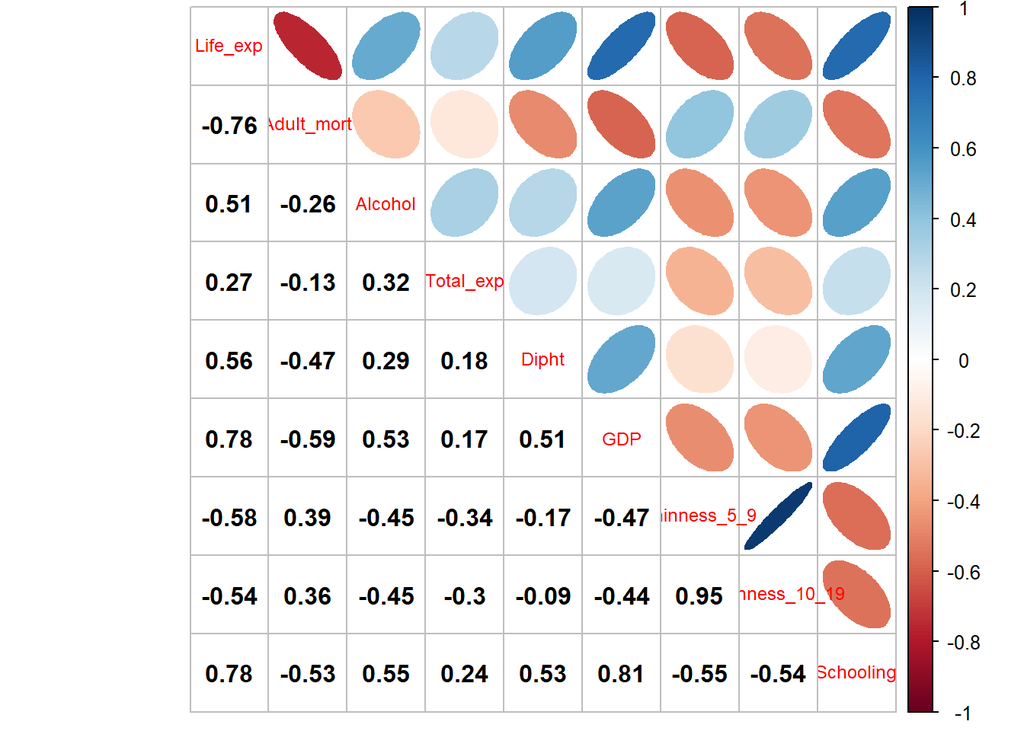

```r
corrplot.mixed(cor(data_new[,-1]), lower.col = 'black', upper = 'ellipse', number.cex = 1, tl.cex = 0.75)
```

Таким образом, в большинстве случаев положительная и обратная связь между переменными стала незначительно слабее после удаления выбросов (в паре случаев связь, наоборот, незначительно возросла по модулю). Однако и положительная, и обратная связь между переменной Dipht и остальными переменными стала сильнее.

Проверим значимость коэффициентов корреляции. Комбинируем оценку корреляционной матрицы с результатами тестов на значимость:

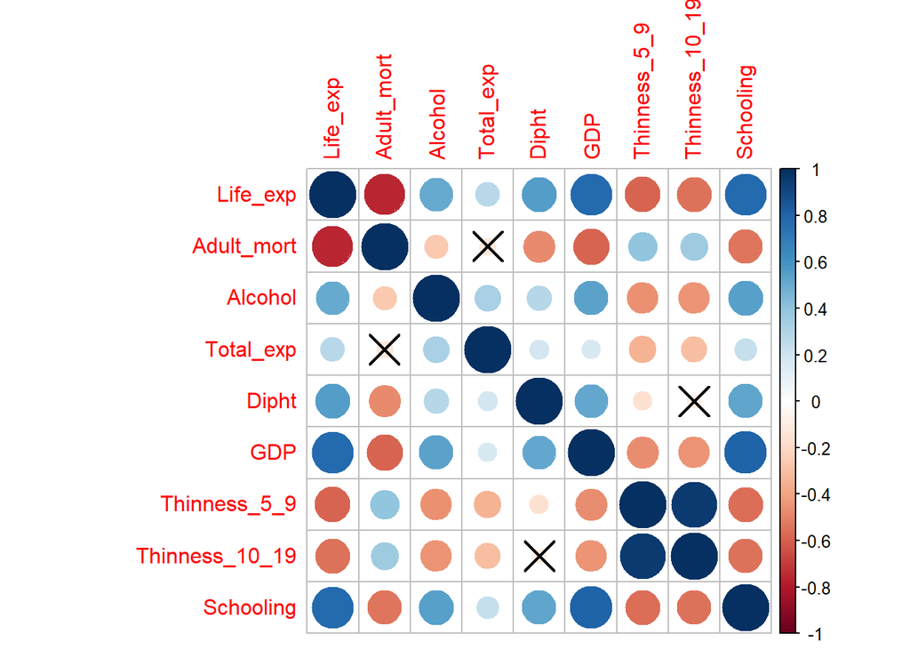

```r
res1 <- cor.mtest(data_new[,-1], conf.level = 0.95)
corrplot(cor(data_new[,-1]), p.mat = res1$p, sig.level = 0.05)
```

Видим статистически незначимые коэффициенты корреляции на 5% уровне значимости (показаны крестами): следовательно, связи между `Thinness_10_19` и `Dopht`, а также между `Total_exp` и `Adult_mort` являются статистически незначимыми. Коэффициенты парной корреляции между зависимой переменной Life_exp и остальными объясняющими переменными являются значимыми.

Итак, связь между зависимой переменной `Life_exp` и остальными объясняющими является в большинстве своем средней, так как значения коэффициентов корреляции больше `0,5`, но меньше `0,8`. Однако до удаления выбросов связь между `Life_exp` и `Total_exp`, а также `Life_exp` и `Dipht` является умеренной (коэффициенты больше 0,3, но меньше 0,5). После удаления выбросов связь между `Life_exp` и `Total_exp` стала слабой (коэффициенты больше 0,1, но меньше 0,3), а связь между `Life_exp` и `Dipht` стала средней. Кроме того, как говорилось выше, в большинстве случаев положительная и обратная связь между переменными стала немного слабее после удаления выбросов. Однако и положительная, и обратная связь между переменной `Dipht` и остальными переменными стала сильнее после удаления выбросов. Можно также отметить, что связь между переменной `Total_exp` и всеми остальными либо слабая, либо умеренная. Сильную связь, очень близкую к линейной функциональной, видим только между переменными `Thinness_5_9` и `Thinness_10_19`, чуть слабее, но всё ещё очень сильную связь – между `GDP` и `Schooling`.